# Delta Distance

Anastasia Bernat

3/18/2021

## Delta Distance Modeling

### All Bugs

#### Problems Noticing

- qqplots of **all** models are not normal and the best fit model is the null model for all. Might need to retransform the distance_diff data either by standardizing it or performing another transformation. (NOTE: only did analyses for bugs that flew and had a distance > 0.)

#### Summary

- (For all bugs) Mass difference between trials matter (gains mass then looses distance).
- (For bugs that flew some distance) Distance or delta distance has nothing to do with the wing2body ratio. It rarely has anything to do with sex or mass or eggs laid. But from the flight_distance.Rmd script, it seems to be heavily dependent on time of day.

#### All Data

```r
source_path = "~/Desktop/git_repositories/SBB-dispersal/avbernat_working_on/Rsrc/"

script_names = c("center_flight_data.R", # Re-centers data
                 "clean_flight_data.R", # Loads and cleans data
                 "unique_flight_data.R",
                 "get_warnings.R",
                 "compare_models.R",
                 "regression_output.R", # Cleans regression outputs; prints in color or B&W
                 "AICprobabilities.R")

for (script in script_names) {
  path = paste0(source_path, script)
  source(path)
}
output_col = FALSE # Change to TRUE if working in Base R or RStudio; FALSE if generating an HTML

data <- read_flight_data("data/all_flight_data-Winter2020.csv")
data_all <- data[[1]]
data_tested <- data[[2]]
d <- create_delta_data(data_tested)
```

```r
d <- d %>%
  filter(!is.na(mass_diff))

R = d$dist_diff
A = d$host_c
B = d$sex_c
C = d$wing2body
D = d$mass_diff
X = d$population

data<-data.frame(R, A, B, C, D, X)

model_script = paste0(source_path,"generic models-gaussian glmer 1-RF + 4-FF REMLF.R")
model_comparisonsAIC(model_script)
```

```
##        [,1]       [,2]       [,3]
## AICs   5447.876   5448.226   5448.782
## models 4          9          7
## probs  0.08438142 0.07083455 0.05364102
##
## m4   R ~ D + (1 | X)
## m9   R ~ B + D + (1 | X)
## m7   R ~ A + D + (1 | X)
```

```r
anova(m0, m4, test="Chisq") # mass matters
```

```
## Data: data
## Models:
## m0: R ~ 1 + (1 | X)
## m4: R ~ D + (1 | X)
##    npar    AIC    BIC  logLik deviance  Chisq Df Pr(>Chisq)
## m0    3 5450.7 5461.6 -2722.4   5444.7
## m4    4 5447.9 5462.4 -2719.9   5439.9 4.8538  1    0.02758 *
## ---
## Signif. codes:  0 '***' 0.001 '**' 0.01 '*' 0.05 '.' 0.1 ' ' 1
```

```r
anova(m4, m9, test="Chisq")
```

```
## Data: data
## Models:
## m4: R ~ D + (1 | X)
## m9: R ~ B + D + (1 | X)
##    npar    AIC    BIC  logLik deviance Chisq Df Pr(>Chisq)
## m4    4 5447.9 5462.4 -2719.9   5439.9
## m9    5 5448.2 5466.4 -2719.1   5438.2  1.65  1      0.199
```

```r
anova(m4, m7, test="Chisq")
```

```
## Data: data
## Models:
## m4: R ~ D + (1 | X)
## m7: R ~ A + D + (1 | X)
##    npar    AIC    BIC  logLik deviance  Chisq Df Pr(>Chisq)
## m4    4 5447.9 5462.4 -2719.9   5439.9
## m7    5 5448.8 5466.9 -2719.4   5438.8 1.0939  1     0.2956
```

```r
dist_model <- lmer(dist_diff ~ mass_diff + (1 | population), data=d, REML=FALSE)
tidy_regression(dist_model, is_color=output_col)
```

```
## lmer dist_diff ~ mass_diff + (1 | population) d FALSE
## AIC:  5447.876 5447.876
## (Intercept)  coeff:  -483.7403092    tval:  -1.728892
## mass_diff    coeff:  -45487.1652921  tval:  -2.222876
```

If a bug gains mass then its distance decreases between trials.

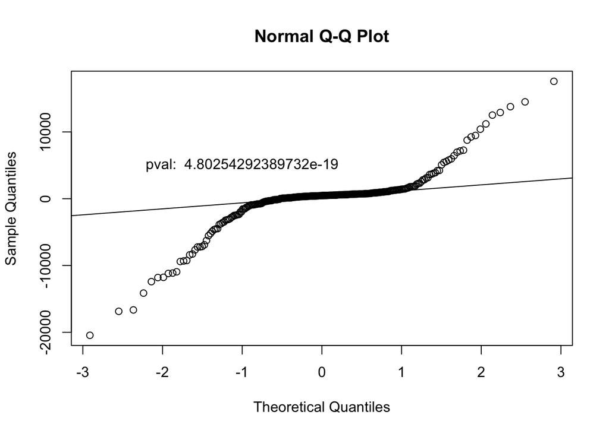

```r
s.test <- paste("pval: ", shapiro.test(residuals(dist_model))$p.value)
qqnorm(resid(dist_model))
qqline(resid(dist_model))
text(-1, 5000, s.test)
```

#### Females Only

```r
d_fem <- d[d$sex == "F",] # very low sample size | also need to recenter
```

**No mass_diff**

```r
R = d_fem$dist_diff
A = d_fem$egg_case
B = d_fem$wing2body
C = d_fem$mass_diff
X = d_fem$population

data<-data.frame(R, A, B, C, X)
model_script = paste0(source_path,"generic models-gaussian glmer 1-RF + 3-FF REMLF.R")
model_comparisonsAIC(model_script)
```

```
##        [,1]
## AICs   1805.96
## models 18
## probs  0.966614
##
## m0   R ~ (1 | X)
```

Null model the best.

#### Males Only

```r
d_male <- d[d$sex == "M",] # need to recenter
```

**No mass_diff**

```r
R = d_male$dist_diff
A = d_male$host_c
B = d_male$wing2body
C = d_male$mass_diff
X = d_male$population

data<-data.frame(R, A, B, C, X)
model_script = paste0(source_path,"generic models-gaussian glmer 1-RF + 3-FF REMLF.R")
model_comparisonsAIC(model_script)
```

```
##        [,1]
## AICs   3620.796
## models 18
## probs  0.9977023
##
## m0   R ~ (1 | X)
```

Null model the best.

### Bugs That Flew Some Distance

```r
### Remove everyone who didn't fly (then remove distances = 0, if that didn't work fully)
data_flew <- data_tested[data_tested$flew_b == 1, ]
data_flew <- data_flew[data_flew$distance > 0, ] # 6 bugs
data_flew <- center_data(data_flew)
d <- create_delta_data(data_flew)
```

```r
d$dist_diff_c = d$dist_diff - mean(d$dist_diff)
d$dist_diff_s =  (d$dist_diff - mean(d$dist_diff)) / sd(d$dist_diff)
```

#### Visualizing Distributions

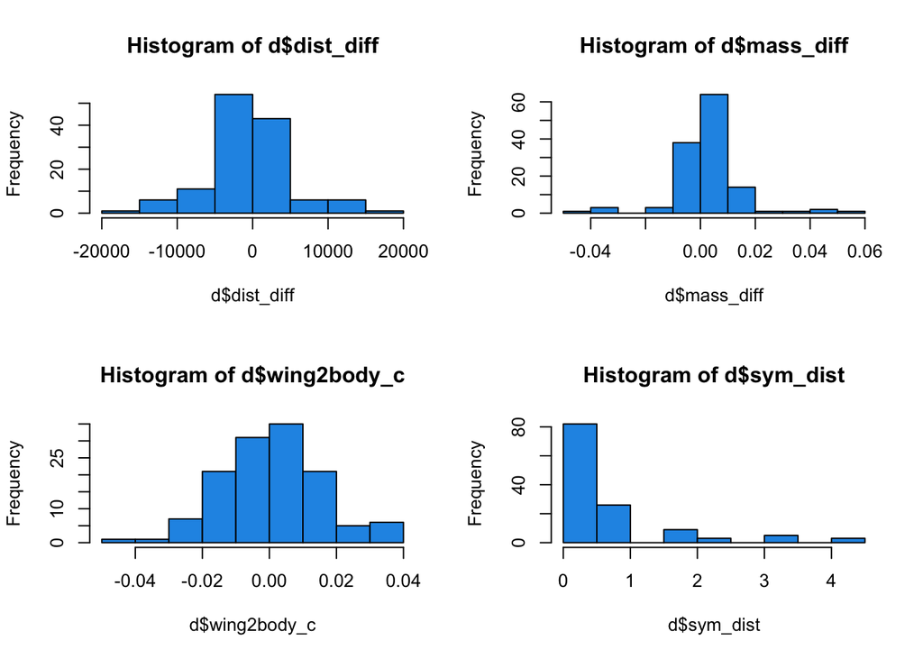

```r
par(mfrow=c(2,2))
hist(d$dist_diff, col=4)
hist(d$mass_diff, col=4)
hist(d$wing2body_c, col=4)
hist(d$sym_dist, col=4)
```

#### Delta Distance

```r
## Test
tidy_regression(lm(dist_diff ~ sym_dist, data=d), is_color = output_col) # no effect of sym_dist
```

```
## lm dist_diff ~ sym_dist d
## AIC:  2564.668
## (Intercept)  coeff:  -153.3373638    Pr(>|t|):  0.7963755
## sym_dist     coeff:  -303.2871167    Pr(>|t|):  0.5595623
```

Removing sym dist and using wing2body.

**No mass_diff**

```r
R = d$dist_diff
A = d$host_c
B = d$sex_c
C = d$wing2body
D = d$mass_diff
X = d$population

data<-data.frame(R, A, B, C, D, X)

model_script = paste0(source_path,"generic models-gaussian glmer 1-RF + 3-FF REMLF.R")
model_comparisonsAIC(model_script)
```

```
##        [,1]
## AICs   2550.871
## models 18
## probs  0.9976969
##
## m0   R ~ (1 | X)
```

```r
dist_model <- lmer(dist_diff ~ 1 + (1 | population), data=d, REML=FALSE)
```

```
## boundary (singular) fit: see ?isSingular
```

```r
tidy_regression(dist_model, is_color=output_col)
```

```
## lmer dist_diff ~ 1 + (1 | population) d FALSE
## AIC:  2565.015 2565.015
## 1    coeff:  -363.0690625    tval:  -0.7736726
```

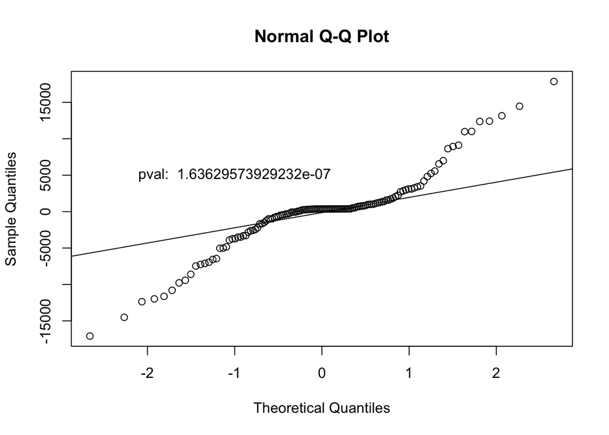

```r
s.test <- paste("pval: ", shapiro.test(residuals(dist_model))$p.value)
qqnorm(resid(dist_model))
qqline(resid(dist_model))
text(-1, 5000, s.test)
```

**Mass_diff**

```r
d <- d %>%
  filter(!is.na(mass_diff))

R = d$dist_diff
A = d$host_c
B = d$sex_c
C = d$wing2body
D = d$mass_diff
X = d$population

data<-data.frame(R, A, B, C, D, X)

model_script = paste0(source_path,"generic models-gaussian glmer 1-RF + 4-FF REMLF.R")
model_comparisonsAIC(model_script)
```

```
##        [,1]      [,2]      [,3]       [,4]       [,5]
## AICs   2565.015  2565.905  2566.167   2566.83    2566.895
## models 113       4         2          1          3
## probs  0.1337176 0.0856842 0.07518488 0.05397731 0.05223007
##
## m0   R ~ 1 + (1 | X)
## m4   R ~ D + (1 | X)
## m2   R ~ B + (1 | X)
## m1   R ~ A + (1 | X)
## m3   R ~ C + (1 | X)
```

```r
anova(m0, m4, test="Chisq") # Adding D does not improve fit
```

```
## Data: data
## Models:
## m0: R ~ 1 + (1 | X)
## m4: R ~ D + (1 | X)
##    npar    AIC    BIC  logLik deviance  Chisq Df Pr(>Chisq)
## m0    3 2565.0 2573.6 -1279.5   2559.0
## m4    4 2565.9 2577.3 -1279.0   2557.9 1.1099  1     0.2921
```

Null is the best model again.

#### Females Only

```r
d_fem <- d[d$sex == "F",] # very low sample size | also need to recenter
```

**No mass_diff**

```r
R = d_fem$dist_diff
A = d_fem$host_c
B = d_fem$wing2body
C = d_fem$mass_diff
X = d_fem$population

data<-data.frame(R, A, B, C, X)
model_script = paste0(source_path,"generic models-gaussian glmer 1-RF + 2-FF REMLF.R")
model_comparisonsAIC(model_script)
```

```
##        [,1]     [,2]      [,3]      [,4]      [,5]
## AICs   535.1551 536.3418  536.5875  537.3108  538.7764
## models 5        2         1         3         4
## probs  0.392933 0.2170809 0.1919932 0.1337281 0.06426471
##
## m0   R ~ (1 | X)
## m2   R ~ B + (1 | X)
## m1   R ~ A + (1 | X)
## m3   R ~ A + B + (1 | X)
## m4   R ~ A * B + (1 | X)
```

```r
anova(m0, m1, test="Chisq") # Adding A (or B) does not improve fit
```

```
## Data: data
## Models:
## m0: R ~ (1 | X)
## m1: R ~ A + (1 | X)
##    npar    AIC    BIC  logLik deviance  Chisq Df Pr(>Chisq)
## m0    3 535.16 538.93 -264.58   529.16
## m1    4 536.59 541.62 -264.29   528.59 0.5676  1     0.4512
```

**mass_diff**

```r
model_script = paste0(source_path,"generic models-gaussian glmer 1-RF + 3-FF REMLF.R")
model_comparisonsAIC(model_script)
```

```
##        [,1]
## AICs   519.0416
## models 18
## probs  0.9988957
##
## m0   R ~ (1 | X)
```

Null is the best model for both again.

```r
dist_model <- lmer(dist_diff ~ 1 + (1 | population), data=d_fem, REML=FALSE)
```

```
## boundary (singular) fit: see ?isSingular
```

```r
tidy_regression(dist_model, is_color=output_col)
```

```
## lmer dist_diff ~ 1 + (1 | population) d_fem FALSE
## AIC:  535.1551 535.1551
## 1    coeff:  -1217.8142308   tval:  -0.9770083
```

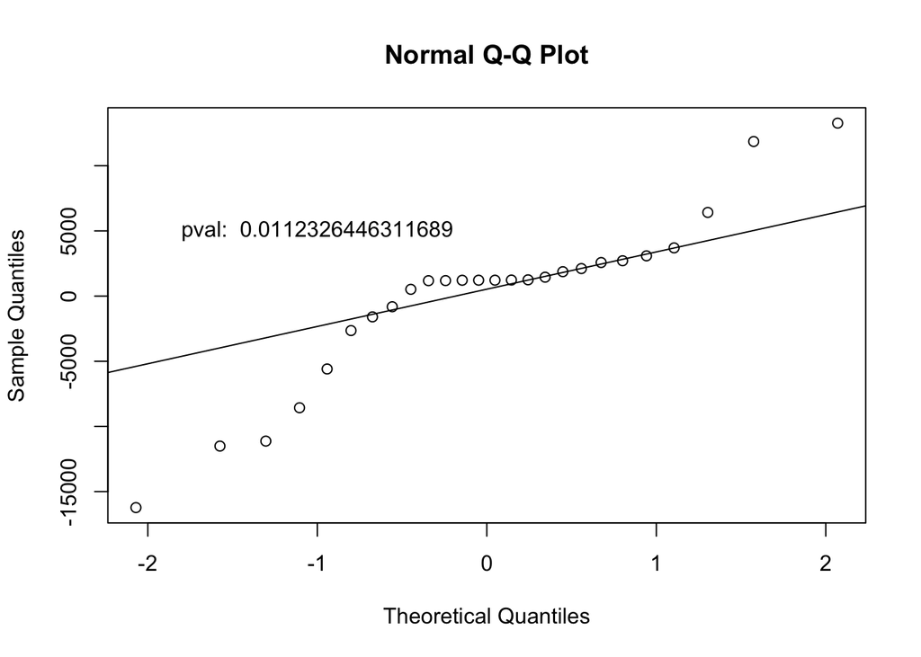

```r
s.test <- paste("pval: ", shapiro.test(residuals(dist_model))$p.value)
qqnorm(resid(dist_model))
qqline(resid(dist_model))
text(-1, 5000, s.test)
```

**egg_case**

**No mass_diff**

```r
R = d_fem$dist_diff
A = d_fem$egg_case
B = d_fem$wing2body
C = d_fem$mass_diff
X = d_fem$population

data<-data.frame(R, A, B, C, X)
model_script = paste0(source_path,"generic models-gaussian glmer 1-RF + 3-FF REMLF.R")
model_comparisonsAIC(model_script)
```

```
##        [,1]
## AICs   519.0416
## models 18
## probs  0.9989612
##
## m0   R ~ (1 | X)
```

Null is the best fit again.

#### Males Only

```r
d_male <- d[d$sex == "M",] # need to recenter
```

**No mass_diff**

```r
R = d_male$dist_diff
A = d_male$host_c
B = d_male$wing2body
C = d_male$mass_diff
X = d_male$population

data<-data.frame(R, A, B, C, X)
model_script = paste0(source_path,"generic models-gaussian glmer 1-RF + 2-FF REMLF.R")
model_comparisonsAIC(model_script)
```

```
##        [,1]      [,2]      [,3]      [,4]
## AICs   2032.329  2033.336  2034.057  2034.973
## models 5         1         2         3
## probs  0.4176423 0.2524608 0.1760721 0.1113632
##
## m0   R ~ (1 | X)
## m1   R ~ A + (1 | X)
## m2   R ~ B + (1 | X)
## m3   R ~ A + B + (1 | X)
```

```r
anova(m0, m1, test="Chisq") # Adding A (or B) does not improve fit
```

```
## Data: data
## Models:
## m0: R ~ (1 | X)
## m1: R ~ A + (1 | X)
##    npar    AIC    BIC  logLik deviance  Chisq Df Pr(>Chisq)
## m0    3 2032.3 2040.2 -1013.2   2026.3
## m1    4 2033.3 2043.8 -1012.7   2025.3 0.9933  1     0.3189
```

**mass_diff**

```r
model_script = paste0(source_path,"generic models-gaussian glmer 1-RF + 3-FF REMLF.R")
model_comparisonsAIC(model_script)
```

```
##        [,1]
## AICs   2018.083
## models 18
## probs  0.9978775
##
## m0   R ~ (1 | X)
```

Null is the best model for both again.

```r
dist_model <- lmer(dist_diff ~ 1 + (1 | population), data=d_male, REML=FALSE)
```

```
## boundary (singular) fit: see ?isSingular
```

```r
tidy_regression(dist_model, is_color=output_col)
```

```
## lmer dist_diff ~ 1 + (1 | population) d_male FALSE
## AIC:  2032.329 2032.329
## 1    coeff:  -145.1928431    tval:  -0.294199
```

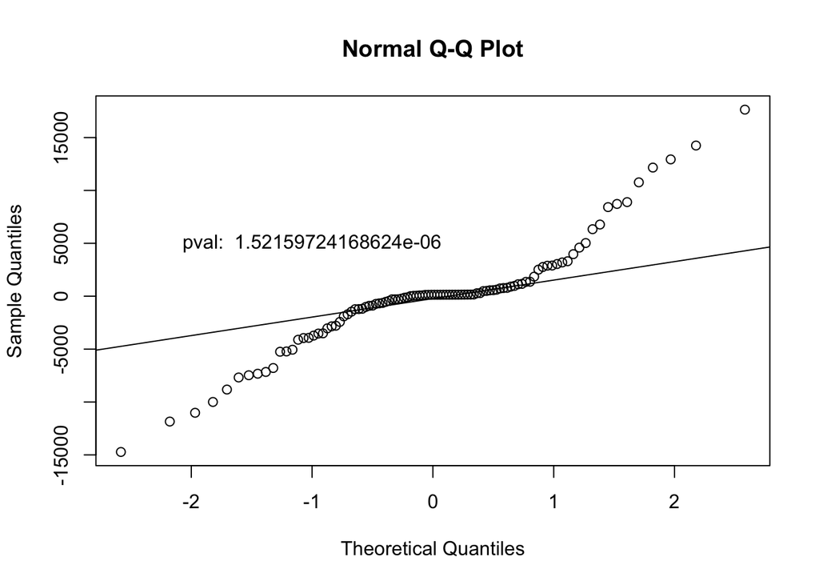

```r
s.test <- paste("pval: ", shapiro.test(residuals(dist_model))$p.value)
qqnorm(resid(dist_model))
qqline(resid(dist_model))
text(-1, 5000, s.test)
```